# 高等数学C · 第19讲 · 行列式：计算与方程组

## 行列式：计算与方程组

高等数学C · 第19讲 · §2.2

王崇宁

[chongningwang.github.io](https://chongningwang.github.io/)

01 · 行列式的定义与计算

02 · 克莱姆法则

## 先化简，再降阶

## 逆序与逆序数

**逆序数 N**：将排列变为 (1, 2, …, n) 所需的**最少相邻对换次数**。

拖拽相邻数字交换

已交换 **0** 次当前逆序数：**3**

(3, 2, 1) → (2, 3, 1) → (2, 1, 3) → (1, 2, 3)，N = 3。

(3, 4, 1, 2) → (3, 1, 4, 2) → (1, 3, 4, 2) → (1, 3, 2, 4) → (1, 2, 3, 4)，N = 4。

## 行列式的等价定义

每行、每列各取一个元素相乘；列号排列的逆序数为 $N$，**偶数取正，奇数取负**。

$$D=\begin{vmatrix}a_{11}&a_{12}&a_{13}\\a_{21}&a_{22}&a_{23}\\a_{31}&a_{32}&a_{33}\end{vmatrix}.$$

| 带符号的乘积 | 带符号的乘积 |
| --- | --- |
| $+a_{11}a_{22}a_{33}$ | $+a_{12}a_{23}a_{31}$ |
| $-a_{11}a_{23}a_{32}$ | $+a_{13}a_{21}a_{32}$ |
| $-a_{12}a_{21}a_{33}$ | $-a_{13}a_{22}a_{31}$ |

**定义 1** $n$ 阶行列式等于每行、每列各取一个元素所得的**所有乘积的带符号之和**：
$$\boxed{D=\sum_{(j_1,\ldots,j_n)}
(-1)^{N(j_1,\ldots,j_n)}a_{1j_1}a_{2j_2}\cdots a_{nj_n}}.$$
求和遍历 $1,2,\ldots,n$ 的全部 $n!$ 个排列。

## 用等价定义计算行列式

**例题 1** 用行列式的等价定义计算，并说明各非零项前的正负号：
$$D=\begin{vmatrix}0&2&0&0\\3&0&0&4\\0&0&2&0\\5&0&0&6\end{vmatrix}.$$

解

第1、3行分别只能选 $a_{12}=2$、$a_{33}=2$。 第2、4行从余下的第1、4列各取一个元素，只有两种选法：

| 列号排列 | 逆序数 | 带符号的乘积 |
| --- | --- | --- |
| $(2,1,3,4)$ | $N=1$，取负号 | $-2\cdot3\cdot2\cdot6=-72$ |
| $(2,4,3,1)$ | $N=4$，取正号 | $+2\cdot4\cdot2\cdot5=80$ |

其余22项都含零，故 $D=-72+80=8$。

## 练习：用定义确定每一项

**练习题 1** 用 定义 1 计算，写出非零项的列号排列及逆序数：
$$D=\begin{vmatrix}1&3&2&4\\1&3&0&2\\0&2&0&-1\\0&5&0&0\end{vmatrix}.$$

解

从第4行向上看：依次只能选第2、4、1、3列。 按行号排列，唯一的非零乘积为 $a_{13}a_{21}a_{34}a_{42}$。

| 列号排列 | 逆序数 | 带符号的乘积 |
| --- | --- | --- |
| $(3,1,4,2)$ | $N=3$ | $-2\cdot1\cdot(-1)\cdot5=10$ |

其余23项都含零，故 $D=\boxed{10}$。

## 回顾：行列变换

**例题 2** 用行列变换计算
$$D=\begin{vmatrix}2&-5&1&2\\-3&7&-1&4\\5&-9&2&7\\4&-6&1&2\end{vmatrix}.$$

解

$$\begin{vmatrix}2&-5&1&2\\-3&7&-1&4\\5&-9&2&7\\4&-6&1&2\end{vmatrix}
\overset{c_1\leftrightarrow c_3}{\longrightarrow}
-\begin{vmatrix}1&-5&2&2\\-1&7&-3&4\\2&-9&5&7\\1&-6&4&2\end{vmatrix}
\overset{\substack{r_2\leftarrow r_2+r_1\\r_3\leftarrow r_3-2r_1\\r_4\leftarrow r_4-r_1}}{\longrightarrow}
-\begin{vmatrix}1&-5&2&2\\0&2&-1&6\\0&1&1&3\\0&-1&2&0\end{vmatrix}$$

$$\overset{r_2\leftrightarrow r_3}{\longrightarrow}
\begin{vmatrix}1&-5&2&2\\0&1&1&3\\0&2&-1&6\\0&-1&2&0\end{vmatrix}
\overset{\substack{r_3\leftarrow r_3-2r_2\\r_4\leftarrow r_4+r_2}}{\longrightarrow}
\begin{vmatrix}1&-5&2&2\\0&1&1&3\\0&0&-3&0\\0&0&3&3\end{vmatrix}
\overset{r_4\leftarrow r_4+r_3}{\longrightarrow}
\begin{vmatrix}1&-5&2&2\\0&1&1&3\\0&0&-3&0\\0&0&0&3\end{vmatrix}.$$

$$D=1\cdot1\cdot(-3)\cdot3=\boxed{-9}.$$

## 练习：自己制造零

**练习题 2** 用行列变换将下列行列式化为**上三角行列式**，再求其值；在箭头上注明每次变换：
$$D=\begin{vmatrix}1&2&3\\2&5&8\\1&3&6\end{vmatrix}.$$

解

$$\begin{vmatrix}1&2&3\\2&5&8\\1&3&6\end{vmatrix}
\overset{\substack{r_2\leftarrow r_2-2r_1\\r_3\leftarrow r_3-r_1}}{\longrightarrow}
\begin{vmatrix}1&2&3\\0&1&2\\0&1&3\end{vmatrix}$$

$$\overset{r_3\leftarrow r_3-r_2}{\longrightarrow}
\begin{vmatrix}1&2&3\\0&1&2\\0&0&1\end{vmatrix},
\qquad D=1\cdot1\cdot1=1.$$

## 练习：利用各行的和

**练习题 3** 利用行列式的性质计算（习题2.2，第2(3)题）：
$$D=\begin{vmatrix}0&1&1&1\\1&0&1&1\\1&1&0&1\\1&1&1&0\end{vmatrix}.$$

解

做 $c_1\leftarrow c_1+c_2+c_3+c_4$，再从第1列提出3：
$$D=3\begin{vmatrix}1&1&1&1\\1&0&1&1\\1&1&0&1\\1&1&1&0\end{vmatrix}.$$

$$\overset{\substack{r_2\leftarrow r_2-r_1\\r_3\leftarrow r_3-r_1\\r_4\leftarrow r_4-r_1}}{\longrightarrow}
3\begin{vmatrix}1&1&1&1\\0&-1&0&0\\0&0&-1&0\\0&0&0&-1\end{vmatrix}
=\boxed{-3}.$$

## 克莱姆法则

[figure not shown]

Gabriel Cramer（1704—1752）

[肖像来源：Wikimedia Commons](https://commons.wikimedia.org/wiki/File:Gabriel_Cramer.jpg)

## 从熟悉的二元方程组出发

[video not shown]

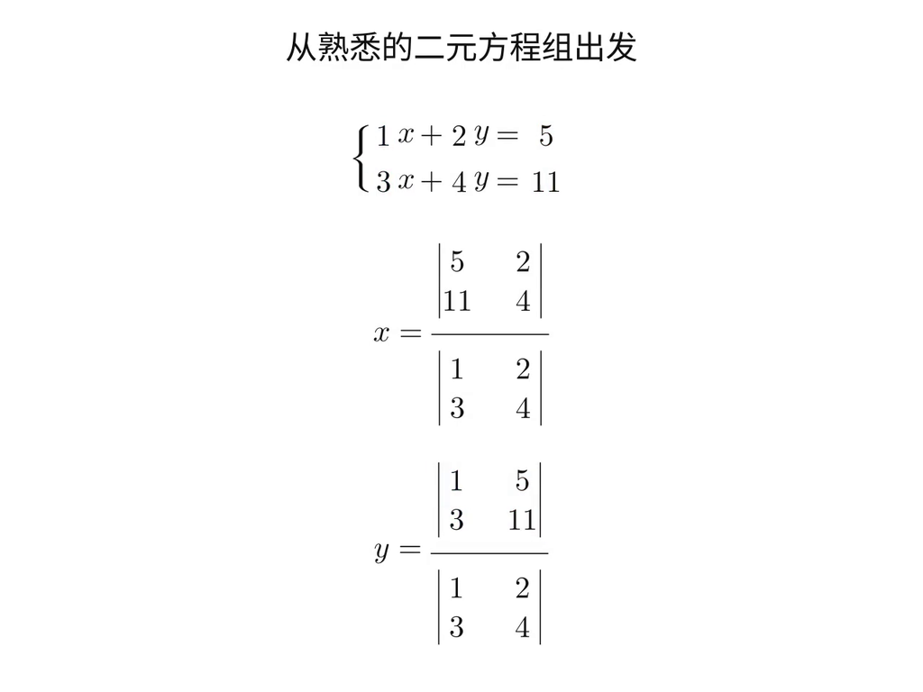

## 一般二元方程组也有同样的形式

$$\begin{cases}a_{11}x_1+a_{12}x_2=b_1,\\a_{21}x_1+a_{22}x_2=b_2,\end{cases}
\qquad D=\begin{vmatrix}a_{11}&a_{12}\\a_{21}&a_{22}\end{vmatrix}.$$

第1式乘 $a_{22}$，减去第2式乘 $a_{12}$：
$$Dx_1=b_1a_{22}-b_2a_{12}
=\begin{vmatrix}b_1&a_{12}\\b_2&a_{22}\end{vmatrix}=D_1.$$

第2式乘 $a_{11}$，减去第1式乘 $a_{21}$：
$$Dx_2=a_{11}b_2-a_{21}b_1
=\begin{vmatrix}a_{11}&b_1\\a_{21}&b_2\end{vmatrix}=D_2.$$

当 $D\ne0$ 时，$x_1=\dfrac{D_1}{D}$，$x_2=\dfrac{D_2}{D}$。这个换列规律能推广到 $n$ 个未知量吗？

## 先检查法则的条件

**定理 1** 对含 $n$ 个未知量、$n$ 个方程的线性方程组：

若系数行列式 $D\ne0$，则方程组有唯一解
$$\boxed{x_j=\dfrac{D_j}{D},\qquad j=1,\ldots,n}.$$

$D_j$：把 $D$ 的**第 $j$ 列**换成方程组右端的常数列，其余列不变。

先算 D；确认 D ≠ 0；再换列求 Dⱼ。

## 克莱姆法则在 $n=3$ 情形的证明

$$\begin{aligned}
a_{11}A_{11}+a_{21}A_{21}+a_{31}A_{31}&=D,\\
a_{12}A_{11}+a_{22}A_{21}+a_{32}A_{31}&=0,\\
a_{13}A_{11}+a_{23}A_{21}+a_{33}A_{31}&=0.
\end{aligned}$$

将原方程组的三式依次乘以 $A_{11}$、$A_{21}$、$A_{31}$ 后相加：

$$\begin{array}{lrclclcl}
Dx= & ( & a_{11}A_{11} & + & a_{21}A_{21} & + & a_{31}A_{31} & )x\\
& +( & a_{12}A_{11} & + & a_{22}A_{21} & + & a_{32}A_{31} & )y\\
& +( & a_{13}A_{11} & + & a_{23}A_{21} & + & a_{33}A_{31} & )z\\
& = & b_1A_{11} & + & b_2A_{21} & + & b_3A_{31} & .
\end{array}$$

由上面三式及 $D_1$ 沿第一列展开，得
$$Dx=b_1A_{11}+b_2A_{21}+b_3A_{31}=D_1.$$

改乘第2、第3列的代数余子式，同理得 $Dy=D_2$、$Dz=D_3$。

若 $D\ne0$，任何解只能是 $x=\dfrac{D_1}{D},\quad y=\dfrac{D_2}{D},\quad z=\dfrac{D_3}{D}$。

## 例题：只求 y

**例题 3** 用克莱姆法则求下列方程组中的 $y$：
$$\begin{cases}x+y+z=6,\\x-y+2z=5,\\2x+y-z=1.\end{cases}$$

解

$$D=\begin{vmatrix}1&1&1\\1&-1&2\\2&1&-1\end{vmatrix}=7\ne0.$$

将第2列换成常数列，其余列不变：
$$D_2=\begin{vmatrix}1&6&1\\1&5&2\\2&1&-1\end{vmatrix}=14.$$

$$y=\dfrac{D_2}{D}=\dfrac{14}{7}=\boxed{2}.$$

## 练习：只求一个未知量

**练习题 4** 对方程组
$$\begin{cases}x+2y+z=0,\\2x-4y+z=1,\\x-y+2z=3,\end{cases}$$
先判断能否用克莱姆法则，再求 $z$。

解

$$D=\begin{vmatrix}1&2&1\\2&-4&1\\1&-1&2\end{vmatrix}=-11\ne0.$$

$$D_3=\begin{vmatrix}1&2&0\\2&-4&1\\1&-1&3\end{vmatrix}=-21,\qquad z=\dfrac{D_3}{D}=\dfrac{21}{11}.$$

## D = 0 时，不能直接下结论

**例题 4** 下面两个方程组的系数行列式都为0。分别判断解的情况。
$$\text{(1)}\ \begin{cases}x+y=2,\\2x+2y=4;\end{cases}
\qquad\text{(2)}\ \begin{cases}x+y=2,\\2x+2y=5.\end{cases}$$

解

1. 第二式是第一式的2倍，有无穷多解：$x=2-t,\ y=t$，$t\in\mathbb R$。
2. 第二式减去第一式的2倍，得到 $0=1$，无解。

D = 0 表示克莱姆比值公式不能使用；还要回到方程组继续判断。

## 求谁，就换谁的列

**例题 5** 用克莱姆法则求指定的未知量：
$$\begin{cases}
2x_1+x_2-5x_3+x_4=8,\\
x_1-3x_2-6x_4=9,\\
2x_2-x_3+2x_4=-5,\\
x_1+4x_2-7x_3+6x_4=0.
\end{cases}$$

已知 $D=27\ne0$。求 $x_3$ 时，将第三列换成 $(8,9,-5,0)^{\mathrm T}$：
$$D_3=\begin{vmatrix}2&1&8&1\\1&-3&9&-6\\0&2&-5&2\\1&4&0&6\end{vmatrix}=-27,
\qquad x_3=\dfrac{-27}{27}=-1.$$

## 选择：展开项的符号

**练习题 5** 四阶行列式的展开式中，乘积 $a_{12}a_{24}a_{31}a_{43}$ 应如何处理？（单选）

A． 是合法的展开项，前面取正号。

B． 是合法的展开项，前面取负号。

C． 行号重复，不是展开项。

D． 列号重复，不是展开项。

解

选 B。行、列号均不重复；列号排列为 $(2,4,1,3)$。 逆序为 $(2,1)$、$(4,1)$、$(4,3)$，共3对，故取负号。

## 选择：法则的适用条件

**练习题 6** 一个含三个未知量、三个方程的线性方程组，其系数行列式 $D=0$。下列说法一定正确的是（单选）：

A． 方程组无解。

B． 方程组有无穷多解。

C． 方程组有唯一解。

D． 不能直接使用克莱姆法则的比值公式求解。

解

选 D。分母为0，比值公式不能使用；是否有解，还需进一步判断。

## 选择：哪个是 D₂？

**练习题 7** 对方程组
$$\begin{cases}2x+y-z=1,\\x+2z=4,\\3x-y+z=2,\end{cases}$$
按 $x,y,z$ 排列系数，求 $y$ 时应使用哪个 $D_2$？（单选）

A． $\begin{vmatrix}2&1&-1\\1&4&2\\3&-1&1\end{vmatrix}$

B． $\begin{vmatrix}1&1&-1\\4&0&2\\2&-1&1\end{vmatrix}$

C． $\begin{vmatrix}2&1&-1\\1&4&2\\3&2&1\end{vmatrix}$

D． $\begin{vmatrix}2&1&1\\1&0&4\\3&-1&2\end{vmatrix}$

解

选 C。把第二列换成 $(1,4,2)^{\mathrm T}$，其余两列不变。

## 选择：变换后的行列式

**练习题 8** 行列式 $D$ 经过**一次对换和若干次倍加**后，化为
$$\begin{vmatrix}1&2&1\\0&1&1\\0&0&-2\end{vmatrix}.$$
原行列式 $D$ 的值是（单选）：

A． $-2$ B． $2$ C． $0$ D． $-1$

解

选 B。变换后的值为 $1\cdot1\cdot(-2)=-2$。

倍加不改变值，一次对换使值变号，故 $D=2$。

## 选择：含参数的方程组

**练习题 9** 设 $t\in\mathbb R$，对方程组
$$\begin{cases}tx+y=1,\\x+ty=2,\end{cases}$$
克莱姆法则的适用条件及所得 $y$ 的表达式，正确的是（单选）：

A． $t\ne1$，$y=\dfrac{2t-1}{t^2-1}$。

B． $t\ne\pm1$，$y=\dfrac{t-2}{t^2-1}$。

C． $t\ne\pm1$，$y=\dfrac{2t-1}{t^2-1}$。

D． $t\ne0$，$y=\dfrac{2t-1}{t^2-1}$。

解

选 C。 $D=\begin{vmatrix}t&1\\1&t\end{vmatrix}=t^2-1\ne0$，故 $t\ne\pm1$。

$D_2=\begin{vmatrix}t&1\\1&2\end{vmatrix}=2t-1$，所以 $y=\dfrac{2t-1}{t^2-1}$。

## 挑战：参数与解的个数

**练习题 10** 设 $t\in\mathbb R$。下列方程组何时有无穷多解（单选）？
$$\begin{cases}tx+y+z=1,\\x+ty+z=1,\\x+y+tz=1\end{cases}$$

A． $t=1$。

B． $t=-2$。

C． $t=1$ 或 $t=-2$。

D． $t\ne1$ 且 $t\ne-2$。

解

$D=(t+2)(t-1)^2$，故只需讨论 $t=1,-2$。

$t=1$：三式都变成 $x+y+z=1$，有无穷多解。

$t=-2$：三式相加得 $0=3$，无解。故选 A。

## 作业19

1． 利用行列式的性质计算：
$$\begin{vmatrix}2&1&4&-1\\3&-1&2&-1\\1&2&3&-2\\5&0&6&-2\end{vmatrix}.$$

2． 利用行列式的性质计算：
$$\begin{vmatrix}ab&-ac&-ae\\-bd&cd&-de\\-bf&-cf&-ef\end{vmatrix}.$$

3． 利用行列式的定义计算：
$$\begin{vmatrix}1&2&5&3\\0&0&-1&4\\3&1&2&1\\0&0&0&2\end{vmatrix}.$$

4． 证明：
$$\begin{vmatrix}a^2&ab&b^2\\2a&a+b&2b\\1&1&1\end{vmatrix}=(a-b)^3.$$

5． 用克莱姆法则解方程组：
$$\begin{cases}x+2y+z=0,\\2x-4y+z=1,\\x-y+2z=3.\end{cases}$$
写出 $D,D_1,D_2,D_3$，并代回核验。